# Kernel density estimates for tidy and geospatial data in the eks package

Tarn Duong https://mvstat.net/tduong/

07 December 2025

## Introduction

Kernel smoothers are essential tools for data analysis due to their ability to convey complex statistical information with concise graphical visualisations. The most widely used kernel smoother is the kernel density estimator (KDE), though there remain some important gaps in the implementation in `R` for specialised data types, most notably for tibbles (tidy data) within the tidyverse, and for simple features (geospatial data) within Geographical Information Systems (GIS) analysis. The `tidy_kde` and `st_kde` functions in the `eks` package fills in these gaps.

## Tidy data example

The data set we focus on is the `crabs` data set from the `MASS` package, with the variables `FL` frontal lobe size (mm), `CW` carapace width (mm) and `sp` species (`B` for blue, `O` for orange).

```r
library(eks)
library(colorspace)
library(ggplot2)
library(dplyr)

## crabs data
data(crabs, package="MASS")
crabs2 <- select(crabs, FL, CW)
xlab <- "Frontal lobe size (mm)"
ylab <- "Carapace width (mm)"
```

The KDE for tidy data is computed by `tidy_kde`. From the output, the scatter plot of the data is generated by `geom_point_ks` and the contour plot of the KDE by `geom_contour_ks`. The bimodal structure of the data distribution, corresponding to the two species, is clearly visible from the KDE plot from `tidy_kde`. This is due to the optimal choice of the matrix of smoothing parameters. This optimal smoothing matrix is the plug-in bandwidth computed by `ks::Hpi`, and it is suitable for a wide range of data sets. For further details of the computation of the kernel density estimate and the bandwidth, see `?ks::kde` and `?ks::Hpi`.

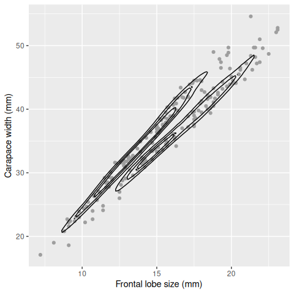

```r
## KDE contour plot + scatter plot
tkde2 <- tidy_kde(crabs2)
gkde2 <- ggplot(tkde2, aes(x=FL, y=CW)) + labs(x=xlab, y=ylab)
gkde2 + geom_point_ks(colour=8) + geom_contour_ks(colour=1)
```

On the other hand, the default bandwidth and the resulting KDE computed by `ggplot2::geom_density_2d` leads to an oversmoothed KDE which does not reveal the data bimodality.

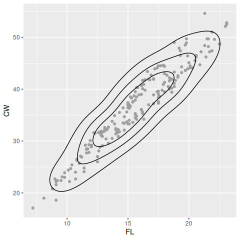

```r
## geom_density_2d KDE contour plot + scatter plot
mkde2 <- ggplot(crabs2, aes(x=FL, y=CW))
mkde2 + geom_point(colour=8) + geom_density_2d(colour=1, bins=4)
```

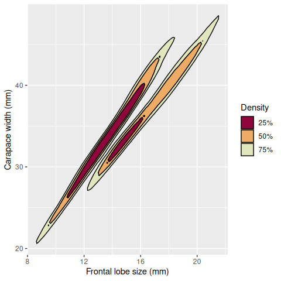

```r
## KDE filled contour plot
gkde2 + geom_contour_filled_ks(colour=1)
```

As an alternative to these discretised contours, the usual `ggplot2::geom_raster` generates a plot with a continuous colour scale.

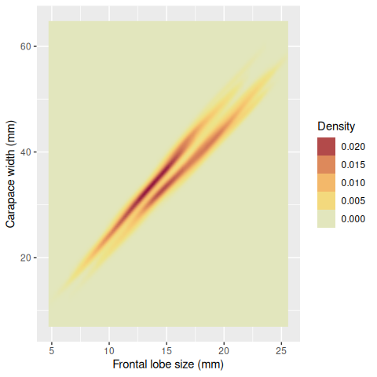

```r
## KDE continuous colour scale plot
gkde2 + geom_raster(aes(fill=estimate), interpolate=TRUE) +
   scale_fill_continuous_sequential(palette="Heat")
```

One of the main advantages of `ggplot2` is its ability to handle grouped data: in this case, the KDE plots for each species. The KDE with blue contours is for the `B` species, and orange contours for the `O` species.

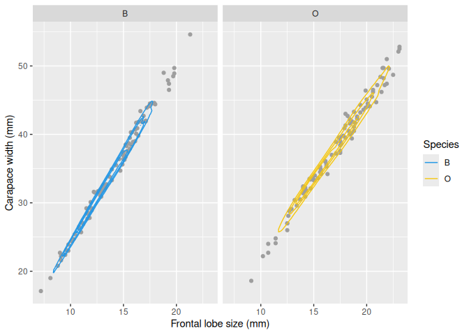

```r
crabs2g <- select(crabs, FL, CW, sp)
crabs2g <- group_by(crabs2g, sp)
tkde2g <- tidy_kde(crabs2g)
gkde2g <- ggplot(tkde2g, aes(x=FL, y=CW, group=sp)) + labs(x=xlab, y=ylab, colour="Species") +
   scale_colour_manual(values=c(4, 7)) +
   guides(colour=guide_legend(title="Species"))
## facetted KDE contour plots + scatter plots
gkde2g + geom_point_ks(colour=8) +
   geom_contour_ks(aes(colour=sp)) + facet_wrap(~sp)
```

The probability contour levels computed in `geom_contour_ks` and `geom_contour_filled_ks` are relative to the grouping variable. So whilst the same probability 25% level is applied to both groups KDE, the height of 25% contour region for the blue species is 0.04143, and for the orange species it is 0.03171. For a direct comparison of different KDEs, it is useful to have a set of fixed contour heights for all KDEs . A heuristic solution is implemented in `contour_breaks`. For the `crabs` data, this gives 0.01418, 0.02690, 0.04143. Since the KDE for the `B` species exceeds the highest level 0.04143, whereas the `O` species KDE doesn’t reach this is level, the former KDE is more peaked.

```
#> Ignoring unknown labels:
#> • colour : "Species"
```

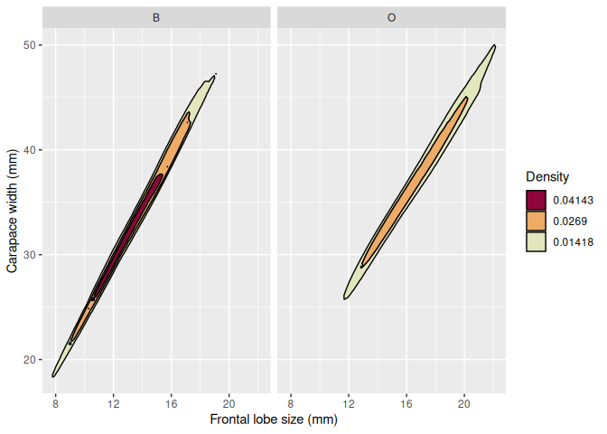

```r
## facetted KDE filled contour plots with fixed contour levels for all facets
bkde2g <- contour_breaks(tkde2g)
gkde2g + geom_contour_filled_ks(breaks=bkde2g, colour=1) + facet_wrap(~sp)
```

## Geospatial data example

GIS for geospatial data analysis in `R` is implemented in the `sf` package, and the `eks` package builds on this. To illustrate geospatial KDE, we focus on the `grevilleasf` data set in the `eks` package. It has 22303 rows, where each row corresponds to an observed grevillea plant in Western Australia. In addition, we utilise `wa`, the geospatial polygon for Western Australia. Both of these geospatial data sets are in the EPSG:7850 (GDA2020/MGA zone 50) projection.

```r
library(sf)

## Grevillea data
data(grevilleasf, package="eks")
grevilleasf <- mutate(grevilleasf, species=factor(species))
paradoxa <- filter(grevilleasf, name %in% "Grevillea paradoxa")
eryngioides <- filter(grevilleasf, name %in% "Grevillea eryngioides")
grevillea_ep <- filter(grevilleasf, name %in% c("Grevillea eryngioides",
   "Grevillea paradoxa"))
grevillea_ep <- group_by(grevillea_ep, name)
xlim <- c(1.2e5, 1.1e6); ylim <- c(6.1e6, 7.2e6)

## WA polygon
data(wa, package="eks")
gwa <- geom_sf(data=wa, fill=NA, colour=1)
```

Since geospatial data can be visualised with both base `R` and `ggplot2` graphics engines, we provide code for both: their outputs are similar due to the standardisation of geospatial maps within GIS. Though these plots can’t be mixed due to fundamental differences between the graphical rendering in base `R` and `ggplot2`.

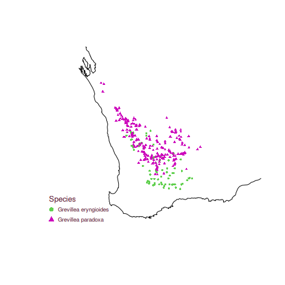

```r
## base R scatter plot
plot(st_geometry(wa), xlim=xlim, ylim=ylim)
plot(st_geometry(eryngioides), add=TRUE, col=3, pch=16, cex=0.5)
plot(st_geometry(paradoxa), add=TRUE, col=6, pch=17, cex=0.5)
mapsf::mf_legend(type="symb", val=c("Grevillea eryngioides", "Grevillea paradoxa"),
   pal=c(3,6), pch=16:17, cex=c(1,1), title="Species", pos="bottomleft")
```

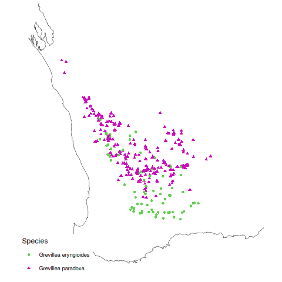

```r
## geom_sf scatter plot
theme_set(ggthemes::theme_map())
ggplot() + gwa +
   geom_sf(data=grevillea_ep, aes(colour=name, shape=name)) +
   coord_sf(xlim=xlim, ylim=ylim) + scale_colour_manual(values=c(3, 6)) +
   guides(colour=guide_legend(title="Species"), shape=guide_legend(title="Species"))
```

The KDE for geospatial data is computed by `st_kde`. The calculations of the KDE, including the bandwidth matrix fo smoothing parameters, are the same as in `tidy_kde`. Though, unlike for `tidy_kde` where the probability contour regions are computed dynamically in `geom_contour_filled_ks`, the 5% to 95% regions are explicitly computed as multipolygons in `st_kde` since this conversion can be computationally heavy to execute for each plot. For display, it is a matter of selecting the appropriate contour regions. The quartile contours 25%, 50%, 75% are selected by default in `geom_contour_filled_ks` for tidy data. This is also the case for the base `R` plot.

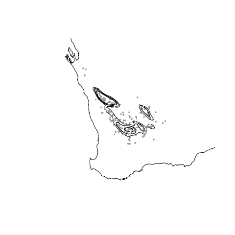

```r
skde1 <- st_kde(paradoxa)

## base R contour plot
plot(st_geometry(wa), xlim=xlim, ylim=ylim)
plot(st_geometry(paradoxa), add=TRUE, pch=16, col=8, cex=0.5)
plot(skde1, add=TRUE, col=NA, border=1, legend=FALSE)
```

On the other hand, we can’t replicate exactly the default contour selection in `geom_sf`, so we first apply the auxiliary function `st_get_contour` to the input of `geom_sf`.

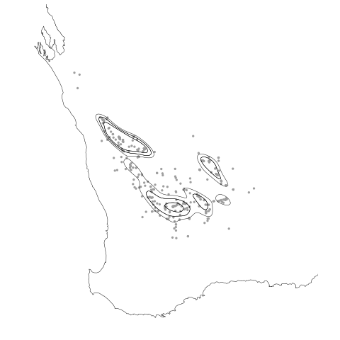

```r
## geom_sf contour plot
gs <- ggplot(skde1) + gwa + ggthemes::theme_map()
gs + geom_sf(data=paradoxa, col=8, size=0.5) +
   geom_sf(data=st_get_contour(skde1), colour=1, fill=NA) +
   coord_sf(xlim=xlim, ylim=ylim)
```

To generate a filled contour plot, the only required change is to set the fill aesthetic to `contperc` (to produce legend labels with density contour percentages) or `estimate` (labels with density estimate levels).

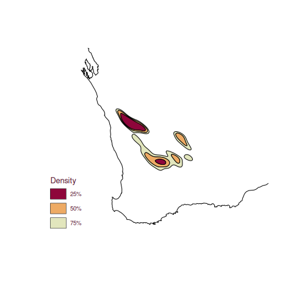

```r
## R base filled contour plot
plot(st_geometry(wa), xlim=xlim, ylim=ylim)
plot(skde1, add=TRUE)
```

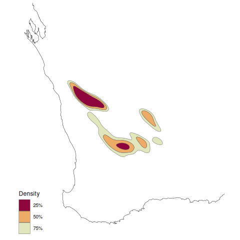

```r
## geom_sf filled contour
gs + geom_sf(data=st_get_contour(skde1), aes(fill=contperc)) +
  coord_sf(xlim=xlim, ylim=ylim)
```

Since the output from `st_kde` is compatible with `geom_sf`, then it is easy to generate multiple maps of related geospatial KDEs. For example, KDEs for each Grevillea species, with probability contour levels or with fixed contour levels:

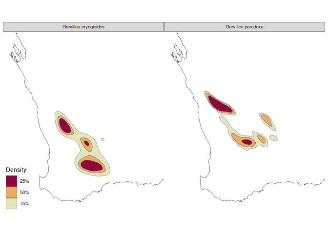

```r
skde1g <- st_kde(grevillea_ep)

## facetted geom_sf filled contour
gs + geom_sf(data=st_get_contour(skde1g), aes(fill=contperc)) +
   facet_wrap(~name) + coord_sf(xlim=xlim, ylim=ylim)
```

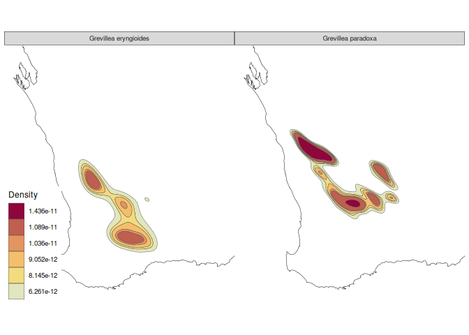

```r
## facetted geom_sf filled contour with fixed contour levels for all facets
bkde1g <- contour_breaks(skde1g, group=TRUE)
gs + geom_sf(data=st_get_contour(skde1g, breaks=bkde1g), aes(fill=estimate)) +
   facet_wrap(~name) + coord_sf(xlim=xlim, ylim=ylim)
```

## References

Chacon, J. E. and Duong, T. (2018). *Multivariate Kernel Smoothing and Its Applications.* Chapman & Hall/CRC Press, Boca Raton.

Duong, T. (2024) Statistical visualisation for tidy and geospatial data in R via kernel smoothing methods in the eks package. *Computational Statistics* https://doi.org/10.1007/s00180-024-01543-9